# relational_data

Brendan Doyle

October 31, 2017

airlines airports planes flights weather

### Exercises 174

1. Use the flight table because it has the origin and dest variables. Use the airports table as well for longitude and latitude of the flight, this table as has dest and origin. Combine flights with airports to get the “origin” airport and to get to “dest” airport location.
2. Their relationship is with the “origin” variable in weather and with “faa” in airports
3. The year, month, day, hour, and origin in weather needs to paired with the same variable names in flight, plus dest.
4. Create a new table for special dates. The main variables would be year, month, and day and matched with the ones of flights table.

### Exercises 177

```r
flights %>%
  arrange(year, month, day, sched_dep_time, carrier, flight) %>%
  mutate(flight_surrogate = row_number()) %>%
  glimpse()
```

```
## Observations: 336,776
## Variables: 20
## $ year             <int> 2013, 2013, 2013, 2013, 2013, 2013, 2013, 201...
## $ month            <int> 1, 1, 1, 1, 1, 1, 1, 1, 1, 1, 1, 1, 1, 1, 1, ...
## $ day              <int> 1, 1, 1, 1, 1, 1, 1, 1, 1, 1, 1, 1, 1, 1, 1, ...
## $ dep_time         <int> 517, 533, 542, 544, 554, 559, 558, 559, 558, ...
## $ sched_dep_time   <int> 515, 529, 540, 545, 558, 559, 600, 600, 600, ...
## $ dep_delay        <dbl> 2, 4, 2, -1, -4, 0, -2, -1, -2, -2, -3, NA, 1...
## $ arr_time         <int> 830, 850, 923, 1004, 740, 702, 753, 941, 849,...
## $ sched_arr_time   <int> 819, 830, 850, 1022, 728, 706, 745, 910, 851,...
## $ arr_delay        <dbl> 11, 20, 33, -18, 12, -4, 8, 31, -2, -3, -8, N...
## $ carrier          <chr> "UA", "UA", "AA", "B6", "UA", "B6", "AA", "AA...
## $ flight           <int> 1545, 1714, 1141, 725, 1696, 1806, 301, 707, ...
## $ tailnum          <chr> "N14228", "N24211", "N619AA", "N804JB", "N394...
## $ origin           <chr> "EWR", "LGA", "JFK", "JFK", "EWR", "JFK", "LG...
## $ dest             <chr> "IAH", "IAH", "MIA", "BQN", "ORD", "BOS", "OR...
## $ air_time         <dbl> 227, 227, 160, 183, 150, 44, 138, 257, 149, 1...
## $ distance         <dbl> 1400, 1416, 1089, 1576, 719, 187, 733, 1389, ...
## $ hour             <dbl> 5, 5, 5, 5, 5, 5, 6, 6, 6, 6, 6, 6, 6, 6, 6, ...
## $ minute           <dbl> 15, 29, 40, 45, 58, 59, 0, 0, 0, 0, 0, 0, 0, ...
## $ time_hour        <dttm> 2013-01-01 05:00:00, 2013-01-01 05:00:00, 20...
## $ flight_surrogate <int> 1, 2, 3, 4, 5, 6, 7, 8, 9, 10, 11, 12, 13, 14...
```

?glimpse() 1. above

Lahman::Batting babynames::babynames nasaweather::atmos fueleconomy::vehicles ggplot2::diamonds

```r
Lahman::Batting %>%
  group_by(playerID, yearID, stint)
```

```
## # A tibble: 102,816 x 22
## # Groups:   playerID, yearID, stint [102,816]
##     playerID yearID stint teamID   lgID     G    AB     R     H   X2B
##        <chr>  <int> <int> <fctr> <fctr> <int> <int> <int> <int> <int>
##  1 abercda01   1871     1    TRO     NA     1     4     0     0     0
##  2  addybo01   1871     1    RC1     NA    25   118    30    32     6
##  3 allisar01   1871     1    CL1     NA    29   137    28    40     4
##  4 allisdo01   1871     1    WS3     NA    27   133    28    44    10
##  5 ansonca01   1871     1    RC1     NA    25   120    29    39    11
##  6 armstbo01   1871     1    FW1     NA    12    49     9    11     2
##  7 barkeal01   1871     1    RC1     NA     1     4     0     1     0
##  8 barnero01   1871     1    BS1     NA    31   157    66    63    10
##  9 barrebi01   1871     1    FW1     NA     1     5     1     1     1
## 10 barrofr01   1871     1    BS1     NA    18    86    13    13     2
## # ... with 102,806 more rows, and 12 more variables: X3B <int>, HR <int>,
## #   RBI <int>, SB <int>, CS <int>, BB <int>, SO <int>, IBB <int>,
## #   HBP <int>, SH <int>, SF <int>, GIDP <int>
```

```r
babynames::babynames %>%
  group_by(year, sex, name)
```

```
## # A tibble: 1,858,689 x 5
## # Groups:   year, sex, name [1,858,689]
##     year   sex      name     n       prop
##    <dbl> <chr>     <chr> <int>      <dbl>
##  1  1880     F      Mary  7065 0.07238433
##  2  1880     F      Anna  2604 0.02667923
##  3  1880     F      Emma  2003 0.02052170
##  4  1880     F Elizabeth  1939 0.01986599
##  5  1880     F    Minnie  1746 0.01788861
##  6  1880     F  Margaret  1578 0.01616737
##  7  1880     F       Ida  1472 0.01508135
##  8  1880     F     Alice  1414 0.01448711
##  9  1880     F    Bertha  1320 0.01352404
## 10  1880     F     Sarah  1288 0.01319618
## # ... with 1,858,679 more rows
```

```r
nasaweather::atmos %>%
  group_by(lat, long, year, month)
```

```
## # A tibble: 41,472 x 11
## # Groups:   lat, long, year, month [41,472]
##         lat   long  year month surftemp  temp pressure ozone cloudlow
##       <dbl>  <dbl> <int> <int>    <dbl> <dbl>    <dbl> <dbl>    <dbl>
##  1 36.20000 -113.8  1995     1    272.7 272.1      835   304      7.5
##  2 33.70435 -113.8  1995     1    279.5 282.2      940   304     11.5
##  3 31.20870 -113.8  1995     1    284.7 285.2      960   298     16.5
##  4 28.71304 -113.8  1995     1    289.3 290.7      990   276     20.5
##  5 26.21739 -113.8  1995     1    292.2 292.7     1000   274     26.0
##  6 23.72174 -113.8  1995     1    294.1 293.6     1000   264     30.0
##  7 21.22609 -113.8  1995     1    295.0 294.6     1000   258     29.5
##  8 18.73043 -113.8  1995     1    298.3 296.9     1000   252     26.5
##  9 16.23478 -113.8  1995     1    300.1 297.8     1000   250     27.5
## 10 13.73913 -113.8  1995     1    300.1 298.7     1000   250     26.0
## # ... with 41,462 more rows, and 2 more variables: cloudmid <dbl>,
## #   cloudhigh <dbl>
```

```r
fueleconomy::vehicles %>%
  group_by(id)
```

```
## # A tibble: 33,442 x 12
## # Groups:   id [33,442]
##       id             make               model  year
##    <int>            <chr>               <chr> <int>
##  1 27550       AM General   DJ Po Vehicle 2WD  1984
##  2 28426       AM General   DJ Po Vehicle 2WD  1984
##  3 27549       AM General    FJ8c Post Office  1984
##  4 28425       AM General    FJ8c Post Office  1984
##  5  1032       AM General Post Office DJ5 2WD  1985
##  6  1033       AM General Post Office DJ8 2WD  1985
##  7  3347 ASC Incorporated                 GNX  1987
##  8 13309            Acura         2.2CL/3.0CL  1997
##  9 13310            Acura         2.2CL/3.0CL  1997
## 10 13311            Acura         2.2CL/3.0CL  1997
## # ... with 33,432 more rows, and 8 more variables: class <chr>,
## #   trans <chr>, drive <chr>, cyl <int>, displ <dbl>, fuel <chr>,
## #   hwy <int>, cty <int>
```

```r
ggplot2::diamonds %>%
  distinct() %>%
  nrow()
```

```
## [1] 53794
```

2. above
3. primary key of “playerID, yearID, stint”, for Batting and the foreign key of “playerID” can join with the same named primary key in Master table. Salaries table shares a primary key of PlayerID with Batting and Master, and a primary key of yearID and teamID with the primary keys of Managers. Then managers table shares the same primary key with AwardsManagers table with yearID and playerID.

```r
flights2 <- flights %>%
  select(year:day, hour, origin, dest, tailnum, carrier)
flights2 %>%
  select(-origin, -dest) %>%
  left_join(airlines, by = "carrier")
```

```
## # A tibble: 336,776 x 7
##     year month   day  hour tailnum carrier                     name
##    <int> <int> <int> <dbl>   <chr>   <chr>                    <chr>
##  1  2013     1     1     5  N14228      UA    United Air Lines Inc.
##  2  2013     1     1     5  N24211      UA    United Air Lines Inc.
##  3  2013     1     1     5  N619AA      AA   American Airlines Inc.
##  4  2013     1     1     5  N804JB      B6          JetBlue Airways
##  5  2013     1     1     6  N668DN      DL     Delta Air Lines Inc.
##  6  2013     1     1     5  N39463      UA    United Air Lines Inc.
##  7  2013     1     1     6  N516JB      B6          JetBlue Airways
##  8  2013     1     1     6  N829AS      EV ExpressJet Airlines Inc.
##  9  2013     1     1     6  N593JB      B6          JetBlue Airways
## 10  2013     1     1     6  N3ALAA      AA   American Airlines Inc.
## # ... with 336,766 more rows
```

### Exercises 186

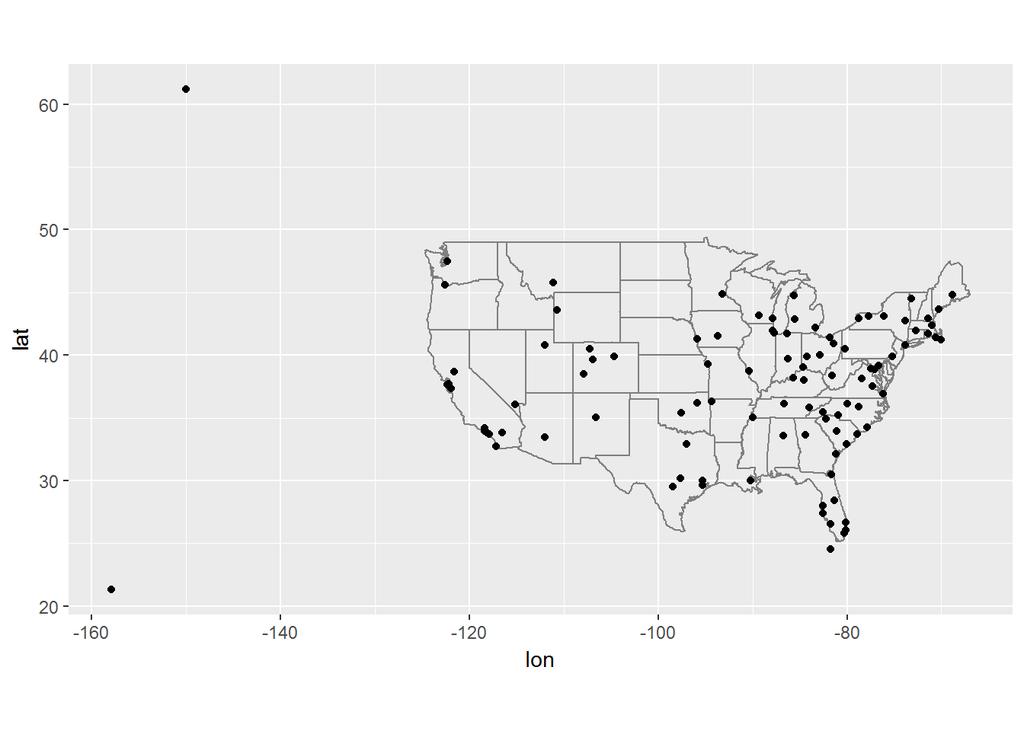

```r
airports %>%
  semi_join(flights, c("faa" = "dest")) %>%
  ggplot(aes(lon, lat)) +
    borders("state") +
    geom_point() +
    coord_quickmap()
```

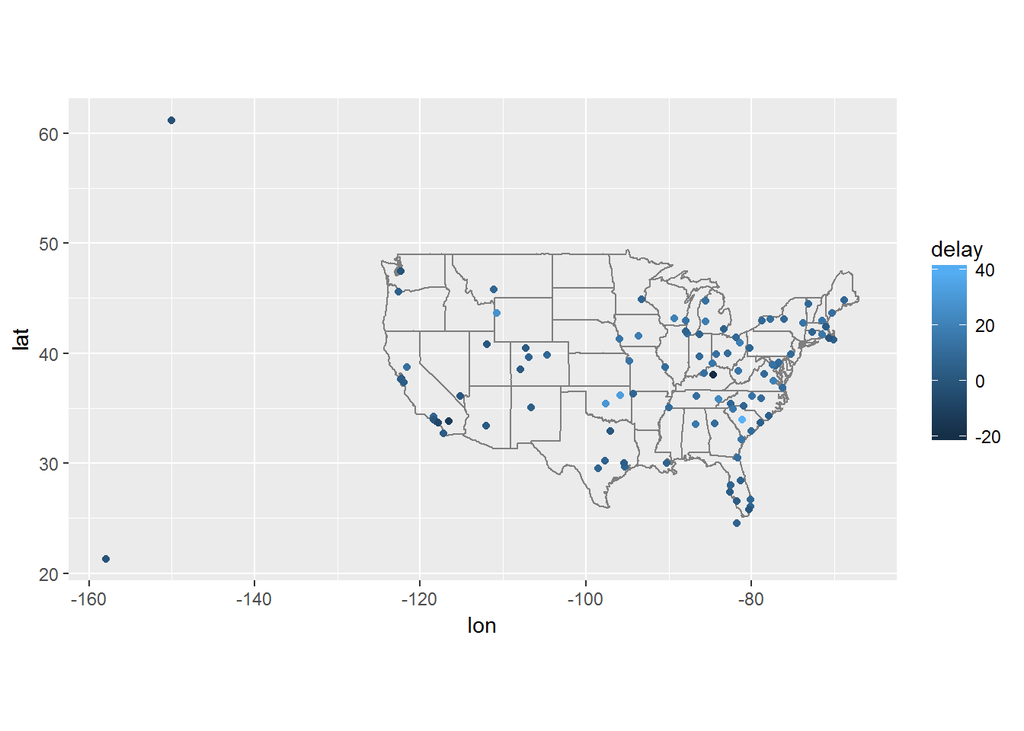

```r
avg_dest_delays <-
  flights %>%
  group_by(dest) %>%
  summarise(delay = mean(arr_delay, na.rm = TRUE)) %>%
  inner_join(airports, by = c(dest = "faa"))

avg_dest_delays %>%
  ggplot(aes(lon, lat, colour = delay)) +
    borders("state") +
    geom_point() +
    coord_quickmap()
```

1. above

```r
flights %>%
  left_join(airports, by = c(dest = "faa")) %>%
  left_join(airports, by = c(origin = "faa")) %>%
  head()
```

```
## # A tibble: 6 x 33
##    year month   day dep_time sched_dep_time dep_delay arr_time
##   <int> <int> <int>    <int>          <int>     <dbl>    <int>
## 1  2013     1     1      517            515         2      830
## 2  2013     1     1      533            529         4      850
## 3  2013     1     1      542            540         2      923
## 4  2013     1     1      544            545        -1     1004
## 5  2013     1     1      554            600        -6      812
## 6  2013     1     1      554            558        -4      740
## # ... with 26 more variables: sched_arr_time <int>, arr_delay <dbl>,
## #   carrier <chr>, flight <int>, tailnum <chr>, origin <chr>, dest <chr>,
## #   air_time <dbl>, distance <dbl>, hour <dbl>, minute <dbl>,
## #   time_hour <dttm>, name.x <chr>, lat.x <dbl>, lon.x <dbl>, alt.x <int>,
## #   tz.x <dbl>, dst.x <chr>, tzone.x <chr>, name.y <chr>, lat.y <dbl>,
## #   lon.y <dbl>, alt.y <int>, tz.y <dbl>, dst.y <chr>, tzone.y <chr>
```

3. There doesn’t appear to be a relationship between age of a plane and its delays as should by the graph below.

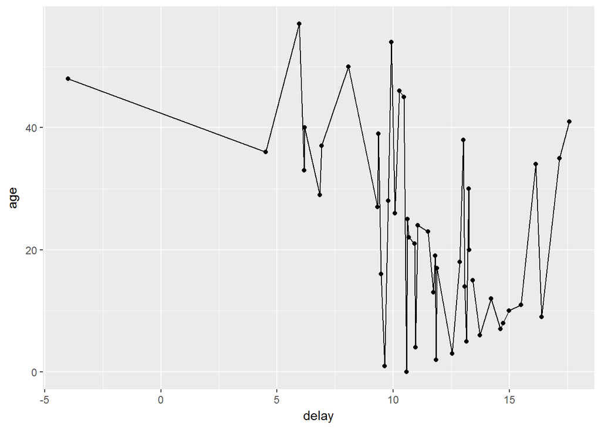

```r
plane_ages <-
  planes %>%
  mutate(age = 2013 - year) %>%
  select(tailnum, age)

flights %>%
  inner_join(plane_ages, by = "tailnum") %>%
  group_by(age) %>%
  filter(!is.na(dep_delay)) %>%
  summarise(delay = mean(dep_delay)) %>%
  ggplot(aes(x = delay, y = age)) +
  geom_point() +
  geom_line()
```

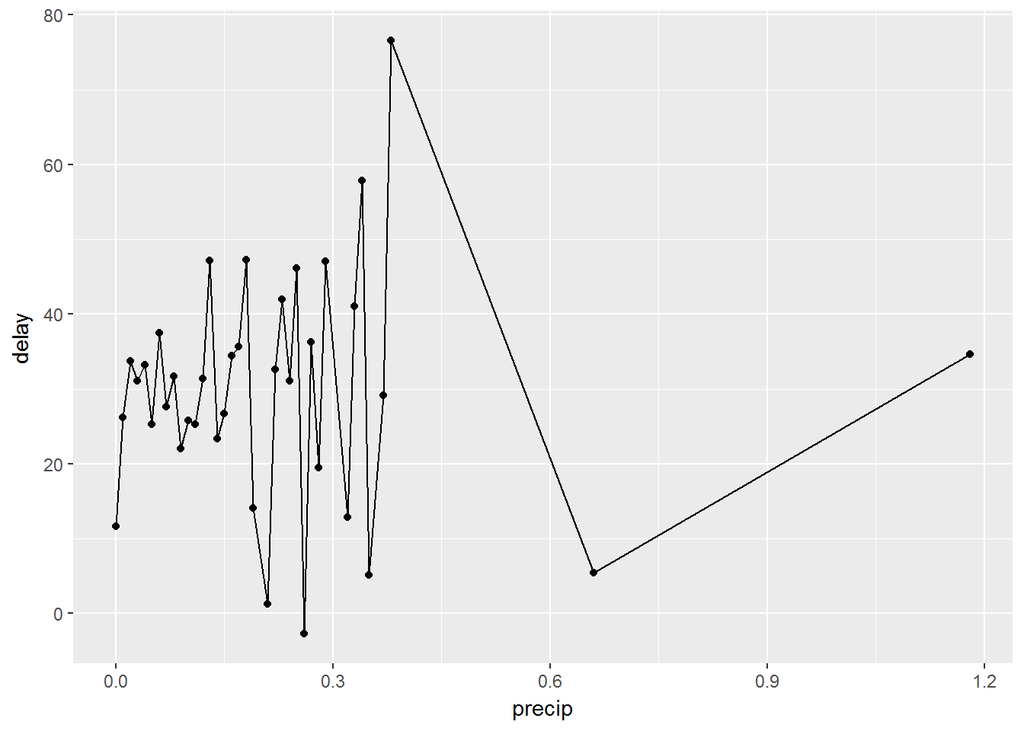

```r
flight_weather <-
  flights %>%
  inner_join(weather, by = c("origin" = "origin",
                            "year" = "year",
                            "month" = "month",
                            "day" = "day",
                            "hour" = "hour"))

flight_weather %>%
  group_by(precip) %>%
  summarise(delay = mean(dep_delay, na.rm = TRUE)) %>%
  ggplot(aes(x = precip, y = delay)) +
    geom_line() + geom_point()
```

5. Google showed that the southeast has a lot of visible weather conditions, specifically storms. The yellow indicates where the biggest delay was which based on the latitude and longitude is 35 (ish) degrees and -85 degrees, respectively. It looks like on the map that it is in Tennessee.

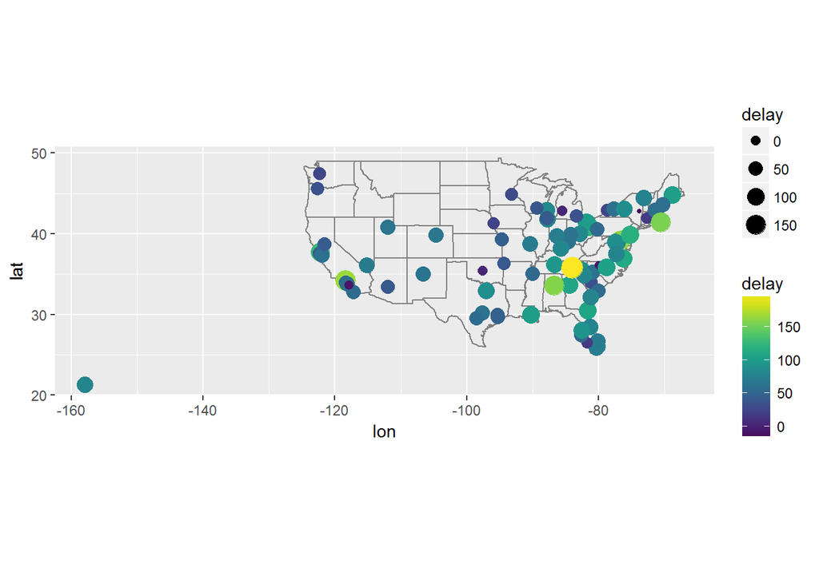

```r
library(viridis)


flights %>%
  filter(year == 2013, month == 6, day == 13) %>%
  group_by(dest) %>%
  summarise(delay = mean(arr_delay, na.rm = TRUE)) %>%
  inner_join(airports, by = c("dest" = "faa")) %>%
  ggplot(aes(y = lat, x = lon, size = delay, colour = delay)) +
  borders("state") +
  geom_point() +
  coord_quickmap()  +
  scale_color_viridis()
```

### Filtering Joins

1. MQ and AA don’t report their tail numbers like other carriers which means the count is repeated more often.

```r
flights %>%
  anti_join(planes, by = "tailnum") %>%
  count(carrier, sort = TRUE)
```

```
## # A tibble: 10 x 2
##    carrier     n
##      <chr> <int>
##  1      MQ 25397
##  2      AA 22558
##  3      UA  1693
##  4      9E  1044
##  5      B6   830
##  6      US   699
##  7      FL   187
##  8      DL   110
##  9      F9    50
## 10      WN    38
```

```r
flights_100<-

  filter(flights) %>%
  group_by(tailnum) %>%
  count() %>%
  filter(n > 100)

flights %>%
  semi_join(flights_100, by = "tailnum")
```

```
## # A tibble: 229,202 x 19
##     year month   day dep_time sched_dep_time dep_delay arr_time
##    <int> <int> <int>    <int>          <int>     <dbl>    <int>
##  1  2013     1     1     1604           1510        54     1817
##  2  2013     1     1     2100           2100         0     2307
##  3  2013     1     2      827            835        -8     1059
##  4  2013     1     2     2014           2020        -6     2256
##  5  2013     1     4     1621           1625        -4     1853
##  6  2013     1     5      834            835        -1     1050
##  7  2013     1     6      832            835        -3     1101
##  8  2013     1     6     2051           2100        -9     2241
##  9  2013     1     7      826            835        -9     1057
## 10  2013     1     7     1444           1445        -1     1659
## # ... with 229,192 more rows, and 12 more variables: sched_arr_time <int>,
## #   arr_delay <dbl>, carrier <chr>, flight <int>, tailnum <chr>,
## #   origin <chr>, dest <chr>, air_time <dbl>, distance <dbl>, hour <dbl>,
## #   minute <dbl>, time_hour <dttm>
```

3. It shows the vehicles by their make and model.

```r
glimpse(fueleconomy::vehicles)
```

```
## Observations: 33,442
## Variables: 12
## $ id    <int> 27550, 28426, 27549, 28425, 1032, 1033, 3347, 13309, 133...
## $ make  <chr> "AM General", "AM General", "AM General", "AM General", ...
## $ model <chr> "DJ Po Vehicle 2WD", "DJ Po Vehicle 2WD", "FJ8c Post Off...
## $ year  <int> 1984, 1984, 1984, 1984, 1985, 1985, 1987, 1997, 1997, 19...
## $ class <chr> "Special Purpose Vehicle 2WD", "Special Purpose Vehicle ...
## $ trans <chr> "Automatic 3-spd", "Automatic 3-spd", "Automatic 3-spd",...
## $ drive <chr> "2-Wheel Drive", "2-Wheel Drive", "2-Wheel Drive", "2-Wh...
## $ cyl   <int> 4, 4, 6, 6, 4, 6, 6, 4, 4, 6, 4, 4, 6, 4, 4, 6, 5, 5, 6,...
## $ displ <dbl> 2.5, 2.5, 4.2, 4.2, 2.5, 4.2, 3.8, 2.2, 2.2, 3.0, 2.3, 2...
## $ fuel  <chr> "Regular", "Regular", "Regular", "Regular", "Regular", "...
## $ hwy   <int> 17, 17, 13, 13, 17, 13, 21, 26, 28, 26, 27, 29, 26, 27, ...
## $ cty   <int> 18, 18, 13, 13, 16, 13, 14, 20, 22, 18, 19, 21, 17, 20, ...
```

```r
glimpse(fueleconomy::common)
```

```
## Observations: 347
## Variables: 4
## $ make  <chr> "Acura", "Acura", "Acura", "Acura", "Acura", "Audi", "Au...
## $ model <chr> "Integra", "Legend", "MDX 4WD", "NSX", "TSX", "A4", "A4 ...
## $ n     <int> 42, 28, 12, 28, 27, 49, 49, 66, 20, 12, 46, 20, 30, 29, ...
## $ years <int> 16, 10, 12, 14, 11, 19, 15, 19, 19, 12, 20, 15, 16, 16, ...
```

```r
fueleconomy::vehicles %>%
  semi_join(fueleconomy::common, by = c("make", "model"))
```

```
## # A tibble: 14,531 x 12
##       id  make   model  year           class           trans
##    <int> <chr>   <chr> <int>           <chr>           <chr>
##  1  1833 Acura Integra  1986 Subcompact Cars Automatic 4-spd
##  2  1834 Acura Integra  1986 Subcompact Cars    Manual 5-spd
##  3  3037 Acura Integra  1987 Subcompact Cars Automatic 4-spd
##  4  3038 Acura Integra  1987 Subcompact Cars    Manual 5-spd
##  5  4183 Acura Integra  1988 Subcompact Cars Automatic 4-spd
##  6  4184 Acura Integra  1988 Subcompact Cars    Manual 5-spd
##  7  5303 Acura Integra  1989 Subcompact Cars Automatic 4-spd
##  8  5304 Acura Integra  1989 Subcompact Cars    Manual 5-spd
##  9  6442 Acura Integra  1990 Subcompact Cars Automatic 4-spd
## 10  6443 Acura Integra  1990 Subcompact Cars    Manual 5-spd
## # ... with 14,521 more rows, and 6 more variables: drive <chr>, cyl <int>,
## #   displ <dbl>, fuel <chr>, hwy <int>, cty <int>
```

4. ?
5. anti_join(flights, airports, by = c(“dest” = “faa”)) tells you the flights that go to an airport that ARE NOT on the faa distinations list.

anti_join(airports, flights, by = c(“faa” = “dest”)) tells you the airports that don’t have flights from a specific destination.

6. Planes can be sold to or acquried by other airlines.